# R Notebook

# Hypothesis Testing Homework

```r
library(tidyverse)
library(janitor)
library(infer)
```

# 1.1 Practical

## Q1

### Explore the dataset and familiarise yourself with it.

```r
msleep <- msleep
summary(msleep)
```

```
     name              genus               vore              order           conservation
 Length:83          Length:83          Length:83          Length:83          Length:83
 Class :character   Class :character   Class :character   Class :character   Class :character
 Mode  :character   Mode  :character   Mode  :character   Mode  :character   Mode  :character




  sleep_total      sleep_rem      sleep_cycle         awake          brainwt
 Min.   : 1.90   Min.   :0.100   Min.   :0.1167   Min.   : 4.10   Min.   :0.00014
 1st Qu.: 7.85   1st Qu.:0.900   1st Qu.:0.1833   1st Qu.:10.25   1st Qu.:0.00290
 Median :10.10   Median :1.500   Median :0.3333   Median :13.90   Median :0.01240
 Mean   :10.43   Mean   :1.875   Mean   :0.4396   Mean   :13.57   Mean   :0.28158
 3rd Qu.:13.75   3rd Qu.:2.400   3rd Qu.:0.5792   3rd Qu.:16.15   3rd Qu.:0.12550
 Max.   :19.90   Max.   :6.600   Max.   :1.5000   Max.   :22.10   Max.   :5.71200
                 NA's   :22      NA's   :51                       NA's   :27
     bodywt
 Min.   :   0.005
 1st Qu.:   0.174
 Median :   1.670
 Mean   : 166.136
 3rd Qu.:  41.750
 Max.   :6654.000
```

```r
glimpse(msleep)
```

```
Rows: 83
Columns: 11
$ name         <chr> "Cheetah", "Owl monkey", "Mountain beaver", "Greater short-tailed shrew", "Cow"…
$ genus        <chr> "Acinonyx", "Aotus", "Aplodontia", "Blarina", "Bos", "Bradypus", "Callorhinus",…
$ vore         <chr> "carni", "omni", "herbi", "omni", "herbi", "herbi", "carni", NA, "carni", "herb…
$ order        <chr> "Carnivora", "Primates", "Rodentia", "Soricomorpha", "Artiodactyla", "Pilosa", …
$ conservation <chr> "lc", NA, "nt", "lc", "domesticated", NA, "vu", NA, "domesticated", "lc", "lc",…
$ sleep_total  <dbl> 12.1, 17.0, 14.4, 14.9, 4.0, 14.4, 8.7, 7.0, 10.1, 3.0, 5.3, 9.4, 10.0, 12.5, 1…
$ sleep_rem    <dbl> NA, 1.8, 2.4, 2.3, 0.7, 2.2, 1.4, NA, 2.9, NA, 0.6, 0.8, 0.7, 1.5, 2.2, 2.0, 1.…
$ sleep_cycle  <dbl> NA, NA, NA, 0.1333333, 0.6666667, 0.7666667, 0.3833333, NA, 0.3333333, NA, NA, …
$ awake        <dbl> 11.90, 7.00, 9.60, 9.10, 20.00, 9.60, 15.30, 17.00, 13.90, 21.00, 18.70, 14.60,…
$ brainwt      <dbl> NA, 0.01550, NA, 0.00029, 0.42300, NA, NA, NA, 0.07000, 0.09820, 0.11500, 0.005…
$ bodywt       <dbl> 50.000, 0.480, 1.350, 0.019, 600.000, 3.850, 20.490, 0.045, 14.000, 14.800, 33.…
```

```r
msleep %>%
  summarise(count_na = sum(is.na(sleep_total)))
```

| count_na |
| --- |
| 0 |

```r
NA
```

## Q2

### Jabberwockies sleep for around 7 hours a night, on average. Perform an appropriate statistical test to determine whether the mean sleep_total in the sampled population of animal types differs from the typical value for jabberwockies.

H0: the mean of sleep_total = 7 hours a night H1: the mean of sleep_total ≠ 7 hours a night sig = 0.05 One-sample Hypothesis Test

```r
sleep_mean <- msleep %>%
  summarise(mean_sleep_total = mean(sleep_total))

sleep_mean
```

[output not shown]

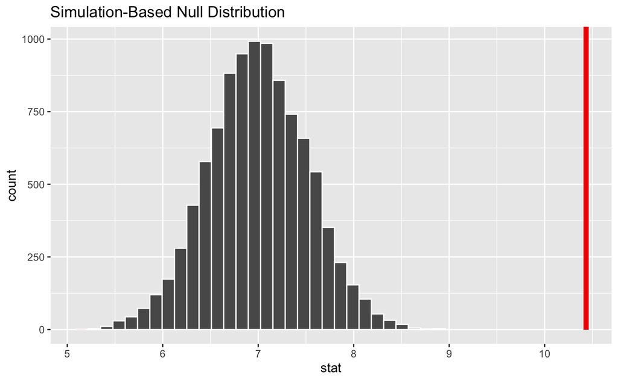

```r
null_distribution_mean <- msleep %>%
  specify(response = sleep_total) %>%
  hypothesise(null = "point", mu = 7) %>%
  generate(10000, type = "bootstrap") %>%
  calculate(stat = "mean")

null_distribution_mean %>%
  visualise(30) +
  shade_p_value(obs_stat = sleep_mean$mean_sleep_total, direction = "both")
```

```r
p_val_mean <- null_distribution_mean %>%
  get_p_value(obs_stat = sleep_mean$mean_sleep_total, direction = "both")
p_val_mean
```

| p_value |
| --- |
| 0 |

## Q3

### Perform an appropriate statistical test to determine whether omnivores sleep for significantly longer than herbivores, on average.

H0: the mean total_sleep for omnivores and the mean total_sleep for herbivores is the same H1: the mean total_sleep for omnivores is greater than (>) the mean total_sleep for herbivores sig = 0.05

Two-sample mean hypothesis test (independent)

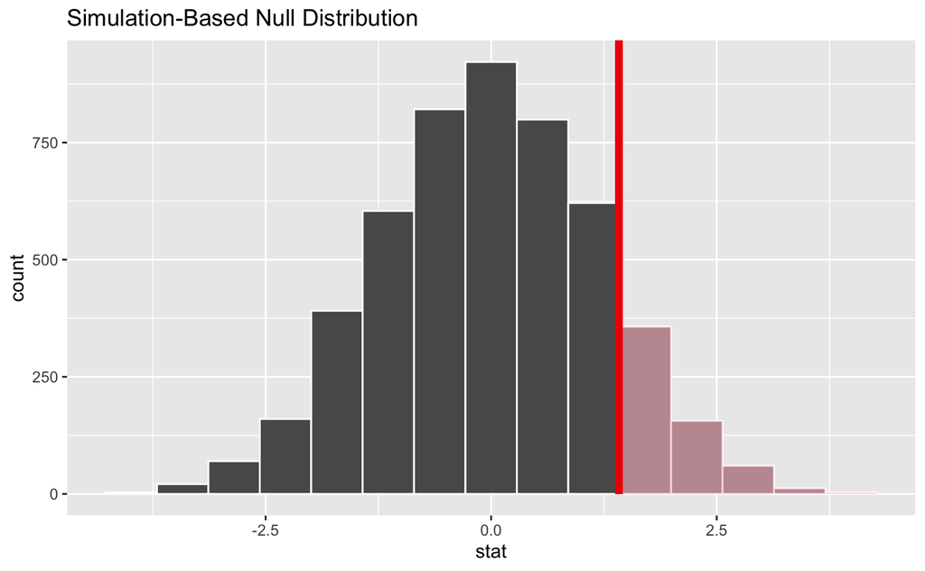

```r
msleep <- msleep %>%
  drop_na(vore)

null_dist_vore <- msleep %>%
  filter(vore %in% c("omni", "herbi")) %>%
  specify(response = sleep_total, explanatory = vore) %>%
  hypothesise(null = "independence") %>%
  generate(reps = 5000, type = "permute") %>%
  calculate(stat = "diff in means", order = c("omni", "herbi"))

obs_stat_vore <- msleep %>%
  filter(vore %in% c("omni", "herbi")) %>%
  specify(sleep_total ~ vore) %>%
  calculate(stat = "diff in means", order = c("omni", "herbi"))

null_dist_vore %>%
  visualise() +
  shade_p_value(obs_stat = obs_stat_vore, direction = "right")
```

```r
p_val_vore <- null_dist_vore %>%
  get_p_value(obs_stat = obs_stat_vore, direction = "right")

p_val_vore
```

| p_value |
| --- |
| 0.1206 |

```r
NA
```

> I can’t get infer to work I’m not seeing what the issue is Error keeps being thrown no matter what stat I chose - it needed a filter

```r
msleep %>%
  group_by(vore) %>%
  summarise(mean_sleep = mean(sleep_total))
```

| vore | mean_sleep |
| --- | --- |
| carni | 10.378947 |
| herbi | 9.509375 |
| insecti | 14.940000 |
| omni | 10.925000 |

## Question 4 ### Perform an appropriate statistical test to determine whether the proportion of domesticated animal types in the population of animal types is greater than 5%

H0: the proportion of domesticated animals is 5% H1: the proportion of domesticated animals is greater than 5% sig = 0.05

One-sample proportion

```r
msleep <- msleep %>%
  mutate(is_domesticated = case_when(
    conservation == "domesticated" ~ TRUE,
    TRUE ~ FALSE
  ))

# assumption: I've imputed all NAs to be non-domesticated
```

```r
observed_prop <- msleep %>%
  summarise(prop_domesticated = mean(is_domesticated))

observed_prop
```

| prop_domesticated |
| --- |
| 0.1315789 |

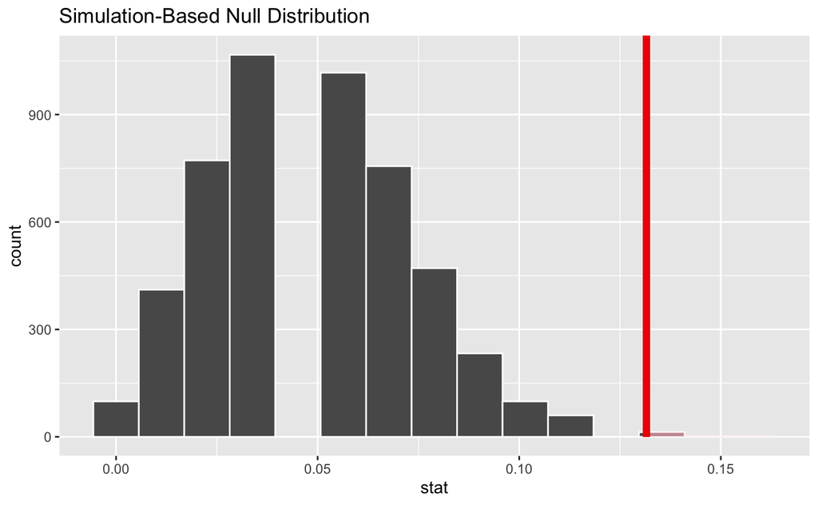

```r
null_dist_prop <- msleep %>%
  specify(response = is_domesticated, success = "TRUE") %>%
  hypothesise(null = "point", p = 0.05) %>%
  generate(reps = 5000, type = "draw") %>%
  calculate(stat = "prop")

null_dist_prop %>%
  visualise() +
  shade_p_value(obs_stat = observed_prop$prop_domesticated, direction = "right")
```

```r
p_val_prop <- null_dist_prop %>%
  get_p_value(obs_stat = observed_prop$prop_domesticated, direction = "right")

p_val_prop
```

| p_value |
| --- |
| 0.003 |

> p value is less than 0.05 therefore we can reject the null hypothesis. There is evidence to suggest that the proportion of domesticated animals is greater than 5%

# 1.2 Defining the hypothesis

## Q1

### Coffee shop

H0: - the proportion of the town that have heard of the coffee shop is 40% - $pi$ = 40% H1: - the proportion of the town that have heard of the coffee shop is greater than 40% - $pi$ > 40%

Method: - one-sample proportion - “draw”/ simulation

## Q2

### A/B test

H0: - the proportion of customers that clicked through was the same for both A and B - p1 - p2 = 0 H1: - the proportion of customers that clicked through was higher for B than A - p2 - p1 > 0

Method: - two-sample proportion - permute

# Q3

### Manufacturing

H0: - the width of the parts is 145mm - $mu$ = 145mm H1: - the width of the parts is not 145mm - $mu$ ≠ 154mm

Method: - bootstrap

# 1.3

# Q1

## Coffee shop

> p-value is more than 0.05 therefore we cannot reject the null hypothesis

# Q2

## A/B test

> p-value is less than threshold, therefore we reject the null hypothesis. There is evidence to suggest that a higher proportion of customers in group B clicked through

## Q3

### Manufactoring

> The p-value is higher that the significance level therefore we fail to reject the null hypothesis